# Science Identity

### [Home](https://pbischoff3.github.io/) | [Data Overview](https://pbischoff3.github.io/data_overview/) | [Multi-Dimensional Analysis](https://pbischoff3.github.io/multi_dimensional_analysis/) | [Models](https://pbischoff3.github.io/models/) | [Conclusion](https://pbischoff3.github.io/Conclusion/)

#### [Science Identity](https://pbischoff3.github.io/models/si/) | [Career Motivation](https://pbischoff3.github.io/models/cm/) | [Intrinsic Motivation](https://pbischoff3.github.io/models/im/) | [Self-Determination](https://pbischoff3.github.io/models/sd/) | [Self-Efficacy](https://pbischoff3.github.io/models/se/) | [Grade Motivation](https://pbischoff3.github.io/models/gm) | [Personal Communal Orientation](https://pbischoff3.github.io/models/per_com_orient/) | [Analysis](https://pbischoff3.github.io/models/analysis/)

Let’s check out Science Identity models.

## Major

Let’s see the influence that the difference in majors have an the average of Science Identity questions:

```
##
## Call:
## glm(formula = science_id_ave ~ major, data = df)
##
## Deviance Residuals:
##      Min        1Q    Median        3Q       Max
## -2.71268  -0.51308   0.08961   0.68732   2.12174
##
## Coefficients:
##                   Estimate Std. Error t value Pr(>|t|)
## (Intercept)         3.7127     0.1096  33.860  < 2e-16 ***
## majorChemistry     -0.0841     0.3660  -0.230 0.818413
## majorComputer_sci   0.2016     0.3660   0.551 0.582158
## majorEarth_sci     -0.3127     0.9304  -0.336 0.737050
## majorEngineering   -0.3660     0.2625  -1.394 0.164311
## majorHealth_sci    -0.6023     0.1325  -4.544 7.97e-06 ***
## majorMathematics   -0.4127     0.6624  -0.623 0.533774
## majorNon_STEM      -0.8344     0.2217  -3.764 0.000201 ***
## majorOther         -0.9064     0.1967  -4.608 6.00e-06 ***
## ---
## Signif. codes:  0 '***' 0.001 '**' 0.01 '*' 0.05 '.' 0.1 ' ' 1
##
## (Dispersion parameter for gaussian family taken to be 0.8535975)
##
##     Null deviance: 290.56  on 311  degrees of freedom
## Residual deviance: 258.64  on 303  degrees of freedom
## AIC: 846.9
##
## Number of Fisher Scoring iterations: 2
```

This shows that those who study Health Science, Non STEM, and Other majors have significantly lower Science Identity.

This is great, but it is difficult to understand this in context until we compare it to the other models.

## Career

Now, let’s look at how career goals affect the average of Science Identity questions:

```
##
## Call:
## glm(formula = science_id_ave ~ career, data = df)
##
## Deviance Residuals:
##      Min        1Q    Median        3Q       Max
## -2.71944  -0.51944   0.06703   0.65574   1.85574
##
## Coefficients:
##                       Estimate Std. Error t value Pr(>|t|)
## (Intercept)             2.8667     0.1342  21.358  < 2e-16 ***
## careereducator         -0.3436     0.2835  -1.212  0.22648
## careerengineer          0.4800     0.2684   1.788  0.07476 .
## careerhealth_care_pro   0.2776     0.1570   1.768  0.07811 .
## careermedical_doctor    0.8528     0.1711   4.984 1.05e-06 ***
## careernon_stem         -0.1867     0.2420  -0.771  0.44104
## careerresearcher        1.0762     0.3658   2.942  0.00351 **
## careerscientist         0.9333     0.2925   3.191  0.00157 **
## careertechnician        0.7000     0.3913   1.789  0.07464 .
## ---
## Signif. codes:  0 '***' 0.001 '**' 0.01 '*' 0.05 '.' 0.1 ' ' 1
##
## (Dispersion parameter for gaussian family taken to be 0.810682)
##
##     Null deviance: 290.56  on 311  degrees of freedom
## Residual deviance: 245.64  on 303  degrees of freedom
## AIC: 830.8
##
## Number of Fisher Scoring iterations: 2
```

This shows that Medical Doctors, Researchers, and Scientists have significantly higher Science Identity.

Now let’s run from another model’s point of view.

## Ethnicity

How about we look at how different ethnicities affect Science Identity?

```
##
## Call:
## glm(formula = science_id_ave ~ ethnicity, data = df)
##
## Deviance Residuals:
##     Min       1Q   Median       3Q      Max
## -2.1784  -0.5784   0.2216   0.6235   1.8216
##
## Coefficients:
##                            Estimate Std. Error t value Pr(>|t|)
## (Intercept)                  4.2800     0.4286   9.985   <2e-16 ***
## ethnicityamerican_indian    -1.3300     0.6429  -2.069   0.0394 *
## ethnicityarab                0.1200     1.0499   0.114   0.9091
## ethnicityasian              -0.9467     0.5346  -1.771   0.0776 .
## ethnicitybiracial           -0.6133     0.5346  -1.147   0.2522
## ethnicitylatinx             -0.9035     0.4876  -1.853   0.0649 .
## ethnicityother              -0.8800     1.0499  -0.838   0.4026
## ethnicitypacific_islander   -0.6800     0.6999  -0.972   0.3321
## ethnicityprefer_not_answer  -0.2300     0.6429  -0.358   0.7208
## ethnicitywhite              -1.1016     0.4327  -2.546   0.0114 *
## ---
## Signif. codes:  0 '***' 0.001 '**' 0.01 '*' 0.05 '.' 0.1 ' ' 1
##
## (Dispersion parameter for gaussian family taken to be 0.918601)
##
##     Null deviance: 290.56  on 311  degrees of freedom
## Residual deviance: 277.42  on 302  degrees of freedom
## AIC: 870.76
##
## Number of Fisher Scoring iterations: 2
```

This shows that American Indians and Caucasians are significantly lower in Science Identity.

One last model. Let’s check it out.

## Medical Conditions

Here is the model according to a presence of medical conditions or not.

```
##
## Call:
## glm(formula = science_id_ave ~ med_condition, data = df)
##
## Deviance Residuals:
##     Min       1Q   Median       3Q      Max
## -2.4103  -0.6183   0.1817   0.7817   1.7817
##
## Coefficients:
##                  Estimate Std. Error t value Pr(>|t|)
## (Intercept)       3.21832    0.05847  55.044   <2e-16 ***
## med_conditionYes  0.19194    0.16537   1.161    0.247
## ---
## Signif. codes:  0 '***' 0.001 '**' 0.01 '*' 0.05 '.' 0.1 ' ' 1
##
## (Dispersion parameter for gaussian family taken to be 0.9332397)
##
##     Null deviance: 290.56  on 311  degrees of freedom
## Residual deviance: 289.30  on 310  degrees of freedom
## AIC: 867.85
##
## Number of Fisher Scoring iterations: 2
```

This shows that medical conditions do not affect Science Identity.

## Conclusion

Now that we have those 4 models according to the demographic that we are interested in, let’s compare them against each other to see which models were best in determining Science Identity.

```
## Parameter                     |        si_mod_1 |       si_mod_2 |       si_mod_3 |       si_mod_4
## --------------------------------------------------------------------------------------------------
## (Intercept)                   |  3.71*** (0.11) | 2.87*** (0.13) | 4.28*** (0.43) | 3.22*** (0.06)
## major (Computer sci)          |     0.20 (0.37) |                |                |
## major (Earth sci)             |    -0.31 (0.93) |                |                |
## major (Engineering)           |    -0.37 (0.26) |                |                |
## major (Chemistry)             |    -0.08 (0.37) |                |                |
## major (Mathematics)           |    -0.41 (0.66) |                |                |
## major (Non STEM)              | -0.83*** (0.22) |                |                |
## major (Other)                 | -0.91*** (0.20) |                |                |
## major (Health sci)            | -0.60*** (0.13) |                |                |
## career (engineer)             |                 |    0.48 (0.27) |                |
## career (health care pro)      |                 |    0.28 (0.16) |                |
## career (medical doctor)       |                 | 0.85*** (0.17) |                |
## career (educator)             |                 |   -0.34 (0.28) |                |
## career (researcher)           |                 |  1.08** (0.37) |                |
## career (scientist)            |                 |  0.93** (0.29) |                |
## career (technician)           |                 |    0.70 (0.39) |                |
## career (non stem)             |                 |   -0.19 (0.24) |                |
## ethnicity (asian)             |                 |                |   -0.95 (0.53) |
## ethnicity (biracial)          |                 |                |   -0.61 (0.53) |
## ethnicity (american indian)   |                 |                |  -1.33* (0.64) |
## ethnicity (arab)              |                 |                |    0.12 (1.05) |
## ethnicity (pacific islander)  |                 |                |   -0.68 (0.70) |
## ethnicity (prefer not answer) |                 |                |   -0.23 (0.64) |
## ethnicity (latinx)            |                 |                |   -0.90 (0.49) |
## ethnicity (other)             |                 |                |   -0.88 (1.05) |
## ethnicity (white)             |                 |                |  -1.10* (0.43) |
## med condition (Yes)           |                 |                |                |    0.19 (0.17)
## --------------------------------------------------------------------------------------------------
## Observations                  |             312 |            312 |            312 |            312
```

This shows everything that we have performed thus far, but now let’s add some statistical analysis to it.

```
## # Comparison of Model Performance Indices
##
## Name     | Model |     AIC | AIC weights |     BIC | BIC weights |    R2 |  RMSE | Sigma
## ----------------------------------------------------------------------------------------
## si_mod_1 |   glm | 846.897 |     < 0.001 | 884.327 |     < 0.001 | 0.110 | 0.910 | 0.924
## si_mod_2 |   glm | 830.803 |       1.000 | 868.233 |       0.995 | 0.155 | 0.887 | 0.900
## si_mod_3 |   glm | 870.764 |     < 0.001 | 911.937 |     < 0.001 | 0.045 | 0.943 | 0.958
## si_mod_4 |   glm | 867.854 |     < 0.001 | 879.083 |       0.004 | 0.004 | 0.963 | 0.966
```

To put all of this in English, we are most interested in those that have higher R^2 values and lower BIC, AIC, and RMSE values. According to that knowledge, it looks like Majors and Careers are the best predictor for Science Identity. Let’s see these together, and with that, we can see whether how they relate.

```
##
## Call:
## glm(formula = science_id_ave ~ major + career, data = df)
##
## Deviance Residuals:
##      Min        1Q    Median        3Q       Max
## -2.90242  -0.50786   0.09214   0.62616   1.89214
##
## Coefficients:
##                       Estimate Std. Error t value Pr(>|t|)
## (Intercept)             3.1483     0.1711  18.405  < 2e-16 ***
## majorChemistry         -0.1234     0.3555  -0.347   0.7288
## majorComputer_sci       0.3236     0.4399   0.736   0.4625
## majorEarth_sci         -0.6515     0.9705  -0.671   0.5026
## majorEngineering        0.0146     0.5250   0.028   0.9778
## majorHealth_sci        -0.3744     0.1445  -2.591   0.0100 *
## majorMathematics       -0.3924     0.6421  -0.611   0.5417
## majorNon_STEM           0.1049     0.3752   0.280   0.7800
## majorOther             -0.5461     0.2134  -2.559   0.0110 *
## careereducator         -0.2057     0.3104  -0.663   0.5081
## careerengineer          0.1426     0.5366   0.266   0.7906
## careerhealth_care_pro   0.3340     0.1573   2.123   0.0346 *
## careermedical_doctor    0.7541     0.1742   4.328 2.06e-05 ***
## careernon_stem         -0.5167     0.3952  -1.307   0.1921
## careerresearcher        0.9032     0.4073   2.218   0.0273 *
## careerscientist         0.7260     0.3026   2.399   0.0171 *
## careertechnician        0.4438     0.4421   1.004   0.3162
## ---
## Signif. codes:  0 '***' 0.001 '**' 0.01 '*' 0.05 '.' 0.1 ' ' 1
##
## (Dispersion parameter for gaussian family taken to be 0.7970471)
##
##     Null deviance: 290.56  on 311  degrees of freedom
## Residual deviance: 235.13  on 295  degrees of freedom
## AIC: 833.16
##
## Number of Fisher Scoring iterations: 2
```

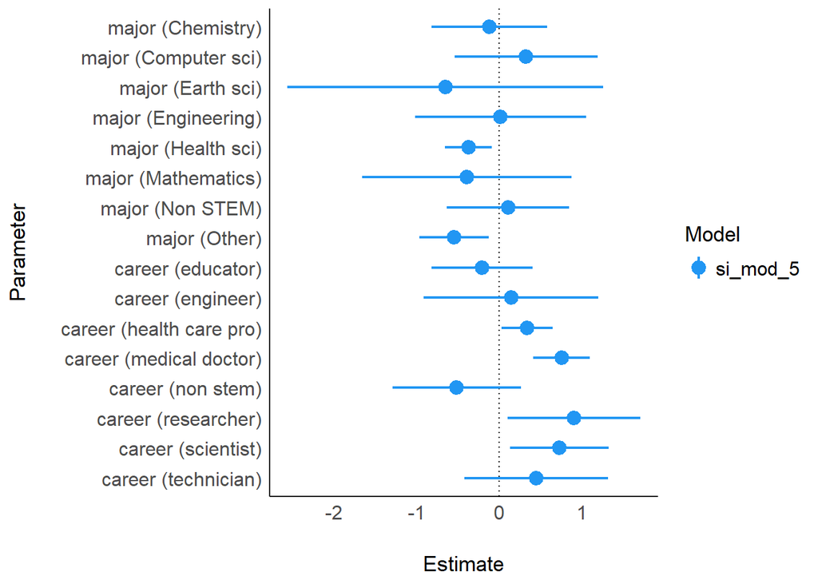

Well awesome, this gives us a great place that we can start in further data analysis in our project.

[figure not shown]

### [**NEXT**](https://pbischoff3.github.io/models/cm/)